# My First Data Visualization

Josh

First, please replace XXX (in the author field in the front matter) with your name!

## Install Packages

Packages perform different jobs in R. Packages allow you to use specific functions in R. They allow R to do new things.

Before we can use a package, we need to install it. We can install it using `install.packages("package_name")`. We only need to run this the first time we install a package.

For our first visualization, we are going to install:

- `tidyverse` - used for loading and wrangling data
- `here` - used to easily access files within a project

## Load Packages

Here, please load the tidyverse and here packages (using the library function).

```r
library(tidyverse)
library(here)
```

## Load Data

### Data downloaded from https://drive.google.com/uc?export=download&id=10iLUo9Yo35valjPmhzlvVlvjx1cd1YQF (or on Canvas).

Please replace XXX with the name gapminder_data, as we will be using that in the next code chunk

```r
gapminder_data <- read_csv(here("gapminder.csv"))
```

## Prepare Data

```r
gapminder_cleaned <- gapminder_data %>%
  # select only the year 2007
  filter(year == "2007") %>%
  # change columns
  mutate(
    # Place any country in Oceania in Asia
    continent = ifelse(continent == "Oceania", "Asia", as.character(continent)),
    # Create the factor order for the continents
    continent = factor(continent, levels=c("Asia", "Americas", "Europe", "Africa"))
  )
```

## Build a Visualization

*Note:* Visualization based on example from https://ggplot2tutor.com/tutorials/gapminder

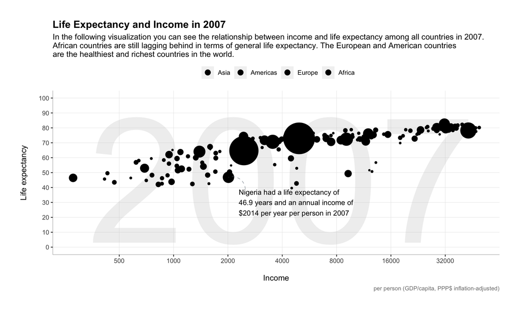

```r
ggplot(data = gapminder_cleaned,
       aes(x = gdpPercap,
           y = lifeExp)) +
      annotate("text", x = 4000, y = 45, hjust = 0.5,
           size = 85, color = "grey80",
           label = "2007", alpha = .3)+
  geom_point(aes(size = pop, fill = continent),
             shape = 20,
             color = "black")+
  guides(size = "none",
         fill = guide_legend(override.aes = list(size = 5)))+
  scale_fill_manual(values = c("Asia" = "#c15dcb",
                                "Americas" = "#057575",
                                "Africa" = "#ff7500" ,
                                "Europe" = "#1E90FF"),
                     name=NULL) +
  scale_x_log10(breaks = c(0500, 1000, 2000, 4000,
                           8000, 16000, 32000, 64000))+
  scale_y_continuous(breaks = seq(0, 120, by = 10))+
  scale_size_continuous(range = c(1, 30))+
  annotate("curve", x = 2500, xend = 2014, y = 39, yend = 46.9,
           color = "#606F7B", linetype = 2, size = .2,  curvature = 0.5)+
  annotate("text", x = 2300, y = 30, hjust = 0,
           size = 3.5,
           label = paste0("Nigeria had a life expectancy of\n",
                          "46.9 years and an annual income of",
                          "\n$2014 per year per person in 2007"))+
    labs(
    x = "Income",
    y = "Life expectancy",
    title = "Life Expectancy and Income in 2007",
    subtitle = paste0("In the following visualization you can see the relationship between income and life expectancy among all countries in 2007.",
                      "\nAfrican countries are still lagging behind in terms of general life expectancy. The European and American countries",
                      "\nare the healthiest and richest countries in the world."),
    caption = "per person (GDP/capita, PPP$ inflation-adjusted)"
  ) +
  theme(
    panel.background =element_rect(fill="white", color="white"),
    plot.margin = unit(rep(1, 4), "cm"),
    plot.title = element_text(size=14, face="bold"),
    plot.caption = element_text(size=8, color="grey50"),
    panel.grid.minor = element_blank(),
    panel.grid.major = element_line(size = 0.2,
                                    color = "#e5e5e5"),
    axis.title.y = element_text(margin = margin(r = 15),
                                size = 11),
    axis.title.x = element_text(margin = margin(t = 15),
                                size = 11),
    axis.line = element_line(color = "#999999",
                             size = 0.2),
    legend.position = "top"
  ) +
  coord_cartesian(ylim = c(0, 100))
```

## Save the plot

```r
ggsave(plot=last_plot(), filename = here("week-1", "gapminder.jpg"), height = 6, width=10)
```

Make sure you can view it - try double-clicking it (or copying the file). It’s yours to keep!

## Gapminder Viz: The Making Of

The following was made with the [`camcorder`](https://github.com/thebioengineer/camcorder) package and shows each ggplot function (the code before the `+` signs) run one after the other.

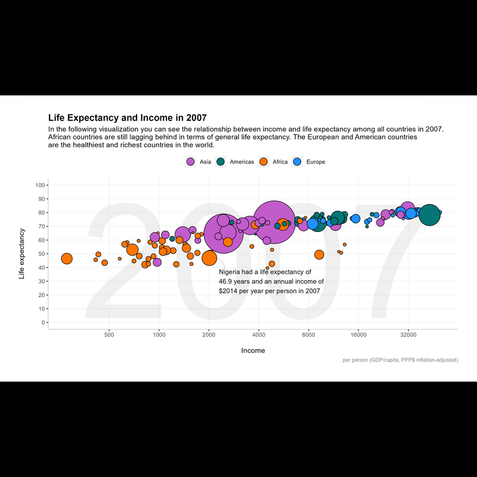

## Rubric

|  | Points Possible | Points Earned |
| --- | --- | --- |
| File knits to HTML | 5 |  |
| Name is added | 2 |  |
| Rmd is submitted. | 2 |  |
| jpg is submitted |  |  |

## Knit and Submit

Complete the following steps to knit and publish your work:

1. First, double-bheck check that the the name of the `author:` in the [YAML header](https://bookdown.org/yihui/rmarkdown-cookbook/rmarkdown-anatomy.html#yaml-metadata) at the very top of this document displays your name. The YAML header controls the style and feel for knitted document but doesn’t actually display in the final output.
2. Next, click the knit button in the toolbar above to “knit” your R Markdown document to a [HTML](https://bookdown.org/yihui/rmarkdown/html-document.html) file that will be saved in your R Project folder. You should see a formatted webpage appear in your Viewer tab in the lower right pan or in a new browser window. Let’s me know if you run into any issues with knitting!
3. Upload the HTML file that is now present in the same folder as this R Markdown file to Canvas to receive credit! Also, please upload the JPG file to receive full credit (so, you will upload two files for this assignment).